# 241218

241218 강의내용

### Matplotlib

- 시각화 유틸리티 역할을 하는 파이썬의 그래프 플로팅 라이브러리

```python
# 설치
# !pip install matplotlib
```

```python
import matplotlib.pyplot as plt
from matplotlib import font_manager

# 폰트 경로 설정  기본값
# fontpath = r'c:\users\NanumGothic.ttf'
fontpath = 'NanumGothic.ttf'
font_manager.fontManager.addfont(fontpath)
plt.rc('font', family='NanumGothic')
plt.rcParams['axes.unicode_minus'] = False
```

### .plot()

- 점(마커)과 점 사이에 선을 그어서 선 그래프로 만든다.

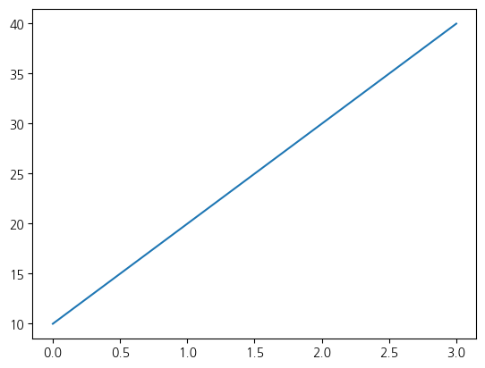

```python
plt.plot([10, 20, 30, 40])   # y축으로 표시 (x축: 0, 1, 2, 3... 자동)
plt.show()
```

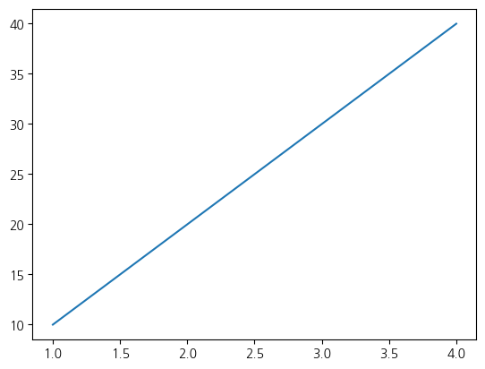

```python
plt.plot([1, 2, 3, 4],[10, 20, 30, 40])   # x축과 y축
plt.show()
```

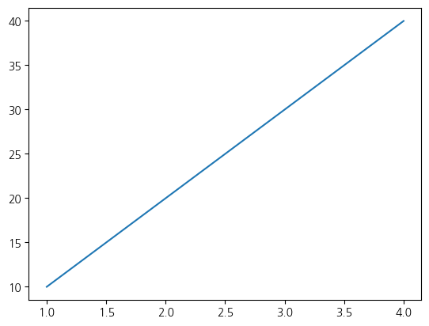

```python
import numpy as np

x = np.arange(1, 5)  # 1, 2, 3, 4
y = np.arange(10, 50, 10)  # 10, 20, 30, 40
plt.plot(x,y)
plt.show()
```

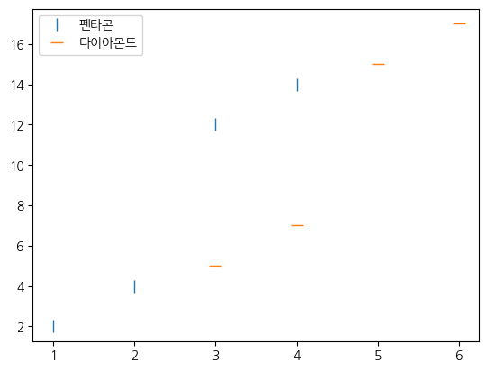

```python
x = np.array([1, 2, 3, 4])
y = np.array([2, 4, 12, 14])
x2 = np.array([3, 4, 5, 6])
y2 = np.array([5, 7, 15, 17])
plt.plot(x,y, '|', label='펜타곤', markerfacecolor='red', markersize=10)
plt.plot(x2,y2, '_', label='다이아몬드', markerfacecolor='blue', markersize=10)
plt.legend() # 범례표시
# plt.axis('off')  # 전체 축 숨기기
plt.show()
```

[기본 마커 종류] Circle: o Squre: s Triangle Up: ^ Triangle Down: v Diamont: D Pentagon: P Hexagon: h Plus: + Cross: x Star: * Vertical Line: | Horizontal Line: _

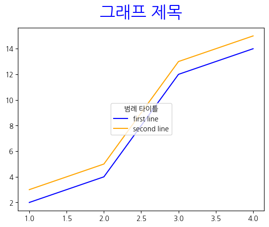

```python
x = np.array([1, 2, 3, 4])       # x 축의 값
y1 = np.array([2, 4, 12, 14])    # 첫 번째 선에 대한 y 축의 값
y2 = np.array([3, 5, 13, 15])    # 두 번째 선에 대한 y 축의 값

plt.title('그래프 제목', loc='center', fontsize=24, color='blue', pad=15)
plt.plot(x, y1, label='first line', color='blue')  #  color: 선색깔
plt.plot(x, y2, label='second line', color='orange')
plt.legend(title="범례 타이틀", loc='center')    # 범례
plt.show()
```

[위치값 종류] 'upper right': 오른쪽 상단 'upper left': 왼쪽 상단 'lower left': 왼쪽 하단 'lower right': 오른쪽 하단 'right': 오른쪽 중앙 'center left': 왼쪽 중앙 'center right': 오른쪽 중앙 'lower center': 하단 중앙 'upper center': 상단 중앙 'center': 중앙[그리드 선 색깔] 파란 b 초록 g 빨간 r 청록 c 보라 m 노랑 y 검정 k 흰색 w[그리드 선 스타일] '-', '--', '-.', ':', 'None', ' ', '', 'solid', 'dashed', 'dashdot', 'dotted' soid(실선) '-' dotted(점선) '.' dashed(대시선) '--' dashdot(대시-점 선) '-.' none ''

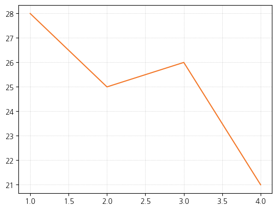

```python
plt.plot([1, 2, 3, 4],[28, 25, 26, 21], color = '#f37626')

# grid(axis: 축방향 (x, y, both(생략가능))
# linestyle(선 스타일): '-', '--', '-.',':' ...
# linewidth(선 너비): 0~1
# alpha(투명도): 0~1
plt.grid(color='k', linestyle=':', linewidth=0.5, alpha=0.3)
plt.show()
```

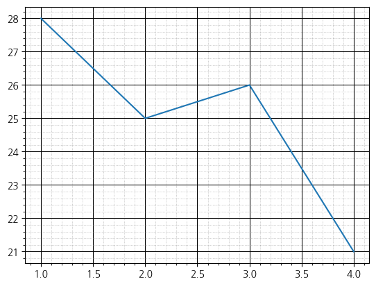

```python
plt.plot([1, 2, 3, 4],[28, 25, 26, 21])

# 기본 그리드 선 추가
plt.grid(which = 'major', color='black', linestyle='-', linewidth=0.75, alpha=1)

# 보조 그리드 선 추가
plt.minorticks_on()  # 보조 그리드에 반드시 필요
plt.grid(which = 'minor', color='gray', linestyle=':', linewidth=0.5, alpha=0.7)
```

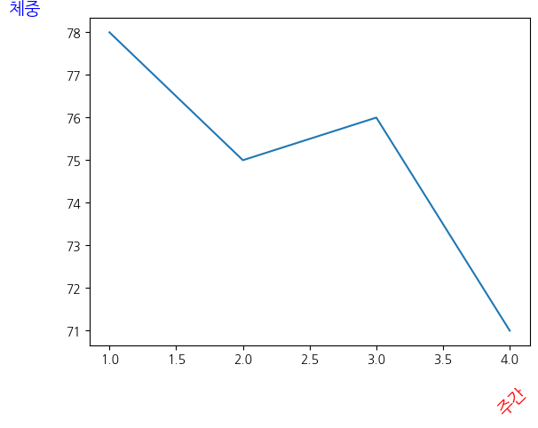

```python
x = [1, 2, 3, 4]
y = [78, 75, 76, 71]

plt.plot(x,y)

plt.xlabel('주간', labelpad = 15, fontsize=14, color='r', loc= 'right', rotation = 45)
plt.ylabel('체중', labelpad = 20, fontsize=14, color='b', loc= 'top', rotation = 0)
plt.show()
```

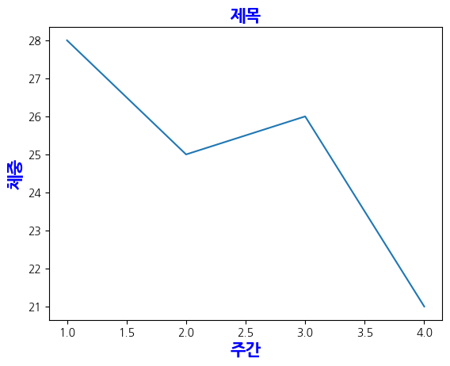

```python
x = [1, 2, 3, 4]
y = [28, 25, 26, 21]

plt.plot(x,y)

font = {'family':'NanumGothic',
       'color':'b',
       'size':15,
       'weight':'bold'}

# fontdict는 xlabel, ylabel, title에 적용 가능

plt.xlabel('주간', fontdict = font)  # 아래와 동일
# plt.xlabel('주간', fontdict = {'family':'NanumGothic','color':'b', 'size':15, 'weight':'bold'})

plt.ylabel('체중', fontdict = font)
plt.title('제목', fontdict = font)
plt.show()
```

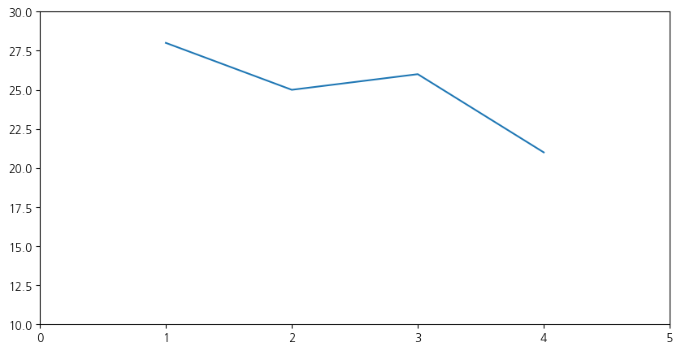

```python
# 범위 직접 지정
plt.figure(figsize=(10, 5))  # 단위: 인치
x = [1, 2, 3, 4]
y = [28, 25, 26, 21]

plt.plot(x,y)
plt.xlim(0, 5)                    # x축의 범위를 0~5로 설정한다.
plt.ylim(10, 30)                  # y축의 범위를 10~30으로 설정한다.
# plt.xlim(left=0, right=5)       # x축의 범위는 왼쪽 0에서 오른쪽 5로 설정한다.
# plt.ylim(bottom=10, top=30)     # y축의 범위는 아래쪽 10에서 위쪽 30으로 설정한다.
plt.axis([0, 5, 10, 30])          # [xmin, xmax, ymin, ymax]
plt.show()
```

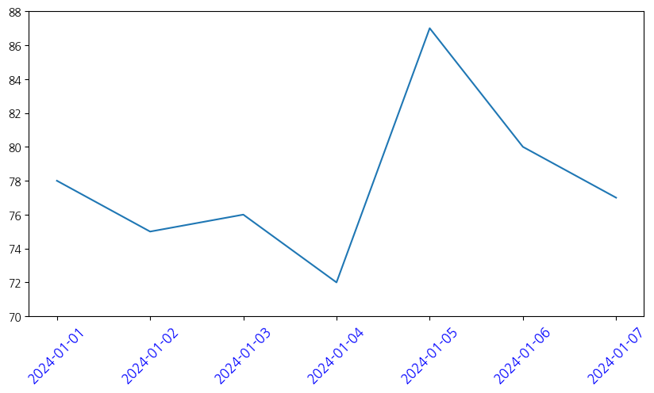

```python
## 눈금설정
plt.figure(figsize=(10, 5))  # 단위: 인치
plt.plot([78, 75, 76, 72, 87, 80, 77])
# plt.xticks([0, 1, 2, 3], labels=['1달', '2달', '3달', '4달'], fontsize=12, color='r', rotation=45)
plt.xticks([0, 1, 2, 3, 4, 5, 6], labels=['2024-01-01', '2024-01-02', '2024-01-03', '2024-01-04', '2024-01-05', '2024-01-06', '2024-01-07'], fontsize=12, color='b', rotation = 45)
plt.yticks(range(70, 90, 2))
plt.show()
```

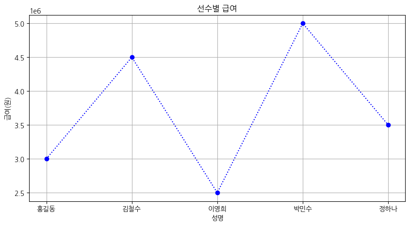

```python
import matplotlib.pyplot as plt

data = {
    '성명':['홍길동','김철수','이영희','박민수','정하나'],
    '급여':[3000000, 4500000, 2500000, 5000000, 3500000]
}

plt.figure(figsize=(10, 5))
plt.plot(data['성명'], data['급여'], marker='o', linestyle=':', color='blue')
plt.title('선수별 급여')
plt.xlabel('성명')
plt.ylabel('급여(원)')
plt.grid()
plt.show()
```

### .bar()

- 데이터 값을 수직 막대 그래프로 표시

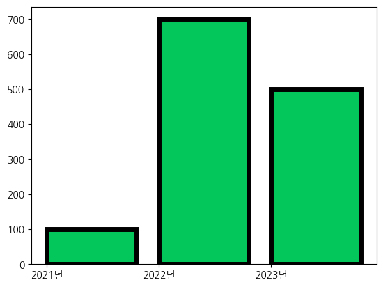

```python
import matplotlib.pyplot as plt

x = [1, 2, 3]
values = [100, 700, 500]
# x: 막대 그래프의 x축에 표시될 범주형 변수, values: 각 막대 그래프의 크기
# width : 너비 비율(0 ~ 1)
# edgecolor : 막대 테두리
# linewidth : 막대 테두리 두께
# align : 'edge' 눈금 왼쪽, 'center' 눈금 가운데
# tick_label : 눈금 라벨 명
plt.bar(x, values, color='#03c75a', width=0.8, edgecolor='black', linewidth=5, align='edge', tick_label=['2021년','2022년','2023년'])
# plt.xticks(x, ['2021년','2022년','2023년'])
plt.show()
```

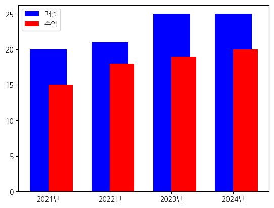

```python
x = [1, 2, 3, 4]
revenue = [20, 21, 25, 25]
profit = [15, 18, 19, 20]

plt.bar(x, revenue, color = 'blue', width = 0.6, align = 'center', label = '매출')
plt.bar(x, profit, color = 'red', width = 0.4, align = 'edge', label = '수익')

plt.xticks(x, ['2021년','2022년','2023년','2024년'])
plt.legend()
plt.show()
```

Home 241218python